# Segmentación: esclerosis múltiple y glioblastoma

Laboratorio 3

Dr. Alejandro Veloz

alejandro.veloz@uv.cl

Ingeniería Biomédica  
Universidad de Valparaíso - Chile

## Objetivos

- Diseñar, implementar y documentar **tres *pipelines*** de segmentación y aplicarlos a dos problemas clínicos.
- Integrar difusión anisotrópica, filtrado en el dominio de Fourier y campos aleatorios de Markov como etapas de esos *pipelines*.
- Evaluar cada *pipeline* contra una referencia, en varios pacientes, con métricas por vóxel y por lesión.
- Atribuir la ganancia de cada etapa mediante ablación y recomendar un *pipeline* por problema.

## Estructura del desafío

1. El desafío
2. Datos
3. Reglas de diseño de los *pipelines*
4. Métodos
5. Evaluación y comparación
6. Informe, rúbrica y entrega

# 1. El desafío

## Problemas

> Construya tres *pipelines* de segmentación distintos, aplíquelos a lesiones de esclerosis múltiple y a un glioblastoma, compárelos con las mismas métricas y en los mismos pacientes, y recomiende uno para cada problema.

**Problema A, esclerosis múltiple.** Lesiones focales de sustancia blanca, hiperintensas en FLAIR, pequeñas y numerosas. Referencia, consenso de tres evaluadores.

**Problema B, glioblastoma.** Una lesión grande y heterogénea con necrosis, anillo realzante y edema, en cuatro secuencias corregistradas. Se segmentan el **tumor completo** y el **tumor realzante**.

## Entregable

Un juoyter notebook que, para cada *pipeline*, recorra en orden: preprocesamiento, segmentación, postproceso y evaluación, con el método explicado paso a paso antes de aplicarlo, y que se cierre con:

- una tabla comparativa de los tres *pipelines* en los dos problemas y en todos los pacientes,
- un estudio de ablación que indique qué etapa aporta la ganancia,
- una recomendación fundamentada por problema.

Pregrado: 3 *pipelines* Postgrado: 5 *pipelines*

# 2. Datos

## 2. Datos

- lab3-ms.zip (32 MB), tres pacientes con esclerosis múltiple de [Open MS data](https://github.com/muschellij2/open_ms_data) (Lesjak et al., 2018), FLAIR, T1 y T2 corregistradas a 1 mm, máscara de encéfalo y lesiones de consenso.
- lab3-gbm.zip (16 MB), dos pacientes con glioblastoma de [LUMIERE](https://doi.org/10.1038/s41597-022-01881-7) (Suter et al., 2022), estudio preoperatorio, T1, T1 con contraste (CT1), T2 y FLAIR corregistradas al atlas MNI a 1 mm, máscara de encéfalo y segmentación de referencia.

## 2. Esclerosis múltiple

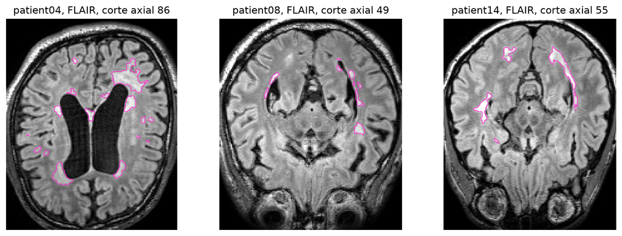

Corte con mayor carga lesional de cada paciente, FLAIR y contorno de la referencia

| Paciente | Edad | Sexo | Tipo | EDSS | Volumen lesional |
| --- | --- | --- | --- | --- | --- |
| patient04 | 25 | M | SP | 6,5 | 40,4 mL |
| patient08 | 41 | M | RR | 5,0 | 6,3 mL |
| patient14 | 42 | M | RR | 4,0 | 13,5 mL |

## 2. Glioblastoma

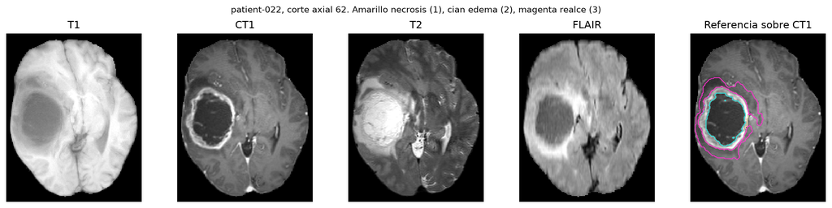

Paciente 022. Las cuatro secuencias y la referencia sobre CT1

Etiquetas de `seg.nii.gz`, 1 núcleo necrótico, 2 edema, 3 tumor realzante. **Tumor completo** es la unión de las tres; **tumor realzante** es la etiqueta 3. La referencia es la segmentación de DeepBraTumIA validada por los autores de la base, no un trazado manual, y conviene tenerlo presente al interpretar los resultados.

Paciente Secuencia Corte axial 62 / 138

Referencia sobre la imagen Opacidad necrosis (1) edema (2) realce (3)

[interactive chart not shown]

imagen

[interactive chart not shown]

referencia

## 2. Carga de los datos

```python
import nibabel as nb
import numpy as np

flair = nb.load("lab3-ms/patient04/FLAIR.nii.gz").get_fdata()
gt    = nb.load("lab3-ms/patient04/consensus_gt.nii.gz").get_fdata() > 0.5
masc  = nb.load("lab3-ms/patient04/brainmask.nii.gz").get_fdata() > 0.5
```

Para el glioblastoma, `seg.nii.gz` reemplaza a `consensus_gt.nii.gz`, y las cuatro secuencias comparten la misma grilla.

# 3. Reglas de diseño de los *pipelines*

## 3. Anatomía de un *pipeline*

Cada *pipeline* tiene cuatro etapas.

| Etapa | Contenido |
| --- | --- |
| Preprocesamiento | Normalización de intensidades y uno o más filtros |
| Segmentación | El algoritmo que decide la clase de cada vóxel |
| Postproceso | Operadores morfológicos y criterios de tamaño o posición |
| Evaluación | Las métricas de la sección 5, con el mismo código para todos |

Los dos problemas debe abordarlos por separado. Puede repetir los *pipeline* en ambos problemas si lo desea.

## 3. Ingredientes obligatorios

Entre los tres *pipelines* deben aparecer, cada uno al menos una vez,

- la **difusión anisotrópica** de Perona y Malik, implementada sin librerías,
- un **filtro en el dominio de Fourier**, implementado con `numpy.fft`, con el espectro mostrado antes y después,
- un **campo aleatorio de Markov**, con la regla de actualización implementada sin librerías.

Los tres *pipelines* deben diferir en la etapa de segmentación.

## 3. Arquetipos sugeridos

|  | *Pipeline* A | *Pipeline* B | *Pipeline* C |
| --- | --- | --- | --- |
| Idea | Determinista | Espectral y agrupamiento | Probabilístico con contexto |
| Preproceso | Normalización, Perona y Malik | Normalización, filtro de Fourier | Normalización, suavizado leve |
| Segmentación | Umbral de Otsu o adaptativo | k-means, FCM o mezcla gaussiana | Mezcla gaussiana e ICM sobre un MRF |
| Posproceso | Morfología | Morfología | Morfología |

Puede proponer otra combinación siempre que respete los ingredientes obligatorios. En el glioblastoma, la segmentación puede usar un vector de intensidades con varias secuencias; en esclerosis múltiple, FLAIR es obligatoria y T1 y T2 optativas.

## 3. Métodos vistos en clases

| Etapa | Métodos | Clase |
| --- | --- | --- |
| Normalización | Ecualización, especificación, CLAHE | Procesamiento de histogramas |
| Filtrado | Perona y Malik; pasa-bajos y homomórfico en Fourier | Ecuación de difusión; filtrado en frecuencia |
| Segmentación | Umbral iterativo, Otsu, adaptativo; k-means, FCM, EM, MRF e ICM | Segmentación I y II |
| Posproceso | Apertura, cierre, componentes conexas, llenado | Morfología matemática |

## 3. Solo para postgrado

Además de los tres *pipelines* obligatorios, debe implementar dos adicionales que incluyan los siguientes métodos:

- Contornor activos (*active contours*, *snakes*).
- Alguna mejora surgida de combinar *region growing* con métodos basados en intensidad (por ejemplo, selección automática de los puntos semilla, selección automática del umbral de crecimiento, etc.)

## 3. Experimento de parámetros

Elija dos parámetros por *pipeline*, como $\kappa$ de la difusión, la frecuencia de corte del filtro o $\beta$ del MRF. El experimento, en esclerosis múltiple, pregunta si los valores elegidos en un paciente sirven para segmentar a otro.

1. **Elegir en el paciente 1.** Segmente con varios valores de cada parámetro y compare cada resultado con la referencia de ese paciente. Grafique el Dice en función del parámetro y quédese con los valores de mayor Dice.
2. **Aplicar a los pacientes 2 y 3.** Segméntelos con esos mismos valores, sin cambiarlos, y calcule su Dice.
3. **Elegir en los pacientes 2 y 3.** Repita el paso 1 en cada uno, con su propia referencia, y calcule el Dice con sus mejores valores.
4. **Comparar.** En los pacientes 2 y 3, el Dice del paso 3 menos el del paso 2 es lo que se pierde al usar valores elegidos en otro paciente. Discuta la diferencia en los resultados.

# 4. Métodos

## 4. Descripción en el notebook

Cada método que participe en un *pipeline* se describe en el cuaderno, **antes de usarlo**, en una celda de texto con la siguiente estructura.

1. Idea del método.
2. Modelo, las ecuaciones que lo definen y el significado de cada símbolo.
3. Parámetros, su efecto y cómo se eligió cada valor en este problema.
4. Límites, cuándo falla y qué consecuencia tiene.

Son obligatorias las descripciones de la normalización, de cada filtro, de cada algoritmo de segmentación, del MRF, del posproceso morfológico y de las métricas.

# 5. Evaluación y comparación

## 5. Métricas por vóxel

Con $S$ la segmentación y $R$ la referencia, dentro de la máscara de encéfalo,
$$\text{Dice} = \frac{2|S\cap R|}{|S|+|R|}, \qquad \text{Jaccard} = \frac{|S\cap R|}{|S\cup R|},$$
$$\text{Sensibilidad} = \frac{|S\cap R|}{|R|}, \qquad \text{VPP} = \frac{|S\cap R|}{|S|},$$
$$\text{Error de volumen} = \frac{|S|-|R|}{|R|}.$$

En el glioblastoma se reportan por separado para el tumor completo y para el tumor realzante.

## 5. Métricas por lesión

En esclerosis múltiple el Dice está dominado por las lesiones grandes. Etiquete las componentes conexas de $R$ y de $S$ y reporte además

- la **tasa de detección**, fracción de lesiones de $R$ que intersectan alguna componente de $S$,
- los **falsos positivos**, componentes de $S$ que no intersectan a $R$,
- el Dice calculado sólo sobre las lesiones de menos de 50 vóxeles.

## 5. Tabla comparativa

Una tabla por problema, con una fila por *pipeline* y paciente, que indique en qué paciente se eligieron los parámetros, sus valores y las métricas. En esclerosis múltiple, resuma con media y desviación estándar los pacientes 2 y 3, por separado para los pasos 2 y 3 del experimento de parámetros (con dos o tres pacientes no hay base para hablar de significancia estadística).

Acompañe la tabla con una figura por problema que superponga, sobre el mismo corte, el contorno de la referencia y el de cada *pipeline*, y con un **mapa de errores** que pinte en colores distintos los falsos positivos y los falsos negativos.

## 5. Ablación

- Para los *pipelines*, repita la evaluación **sin la etapa de filtrado** y **sin el posproceso**, manteniendo lo demás. La diferencia de Dice atribuye la ganancia a cada etapa.
- Para el *pipeline* con MRF, compare con el mismo modelo con $\beta = 0$, que es la clasificación por máxima verosimilitud sin contexto.
- Presente la ablación como una tabla de diferencias respecto del *pipeline* completo.

## 5. Discusión obligatoria

El cierre del notebook debe responder, con referencia a las tablas y figuras, los siguientes puntos.

- Qué *pipeline* recomienda para cada problema y qué etapa explica su ventaja.
- Por qué un mismo *pipeline* se comporta distinto en lesiones pequeñas y numerosas que en una lesión grande y heterogénea.
- Qué aporta el contexto espacial del MRF frente al agrupamiento sin contexto, y a qué costo.
- Qué *pipeline* pierde menos Dice cuando usa valores elegidos en otro paciente, y qué parámetro explica esa pérdida.

# 6. Informe, rúbrica y entrega

## 6. Estructura del notebook

1. Datos, con las figuras de la sección 2 reproducidas.
2. Funciones comunes, carga, normalización, métricas y visualización.
3. *Pipeline* A, descripción de métodos, implementación, ajuste de parámetros, resultados en ambos problemas.
4. *Pipeline* B, ídem.
5. *Pipeline* C, ídem.
6. Comparación, tablas, figuras y ablación.
7. Discusión y recomendación.

## 6. Rúbrica

| Componente | Puntos |
| --- | --- |
| *Pipelines* A, B y C, implementación, descripción de métodos y ajuste (15 cada uno) | 45 |
| Ingredientes obligatorios implementados sin librerías y verificados | 20 |
| Funciones comunes, tablas, figuras y ablación | 20 |
| Discusión y recomendación | 15 |
| Versión tridimensional (bonificación) | +5 |

## Entrega

- *apellido_nombre_l3.ipynb* y *apellido_nombre_l3.pdf*
- Medio: Aula virtual
- Las versiones $\texttt{.pdf}$ corresponden a los archivos $\texttt{.ipynb}$ con las salidas de las celdas visibles.
- Cada descripción de método y cada punto de la discusión van en celdas de texto, junto a las figuras y tablas que los respaldan.
- No respetar las instrucciones significará un descuento de 10 pts.